# El tsunami retrocede

Daniel Gervini

2 de mayo de 2021

El “tsunami” o segunda ola que comenzó en marzo de este año resultó no ser tan grave como habíamos proyectado en [este posteo](https://dgervini.github.io/Coronavirus/Tsunami.html). Para ese análisis habíamos usado datos hasta la primera semana de abril, que fue la de crecimiento más acelerado. Pero pasada Semana Santa, la curva se amesetó en Capital Federal y hoy ya muestra un claro descenso:

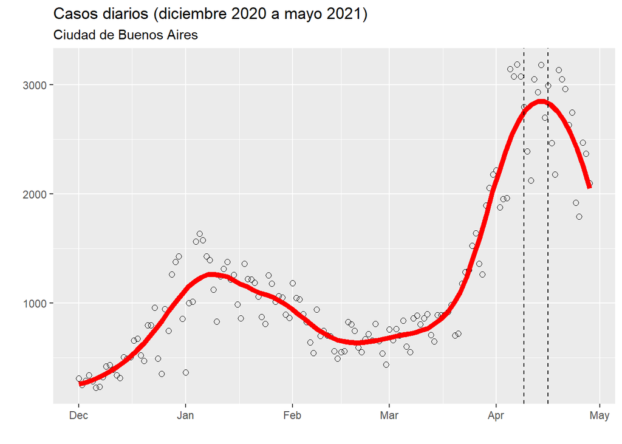

Las dos líneas verticales del gráfico anterior marcan la entrada en vigencia de las restricciones, las “light” del 9 de abril y las más severas del 16 de abril. ¿Explican estas medidas el descenso de casos en Capital? En principio no, ya que el efecto de las medidas se ve recién pasada la ventana epidemiológica de dos semanas, mientras que el gráfico de arriba muestra que la curva se amesetó **al mismo tiempo** que se anunciaron las medidas. Es decir, la tendencia al amesetamiento (cualquiera fuera la causa) **ya estaba en marcha** al momento de anunciarse las medidas.

En este posteo examinamos más en detalle las posibles causas de este súbito amesetamiento, que era imprevisto hasta la primera semana de abril.

## Casos y clases presenciales

Dado que la Capital Federal no suspendió las clases presenciales, es claro que la baja en la curva de casos diarios no puede deberse a ese factor. ¿Cuánto contribuyen los menores de 19 años al total de casos diarios? El siguiente gráfico muestra la proporción diaria de contagiados que representan las franjas etarias de 0-19, 20-29 y 30-49 años de edad:

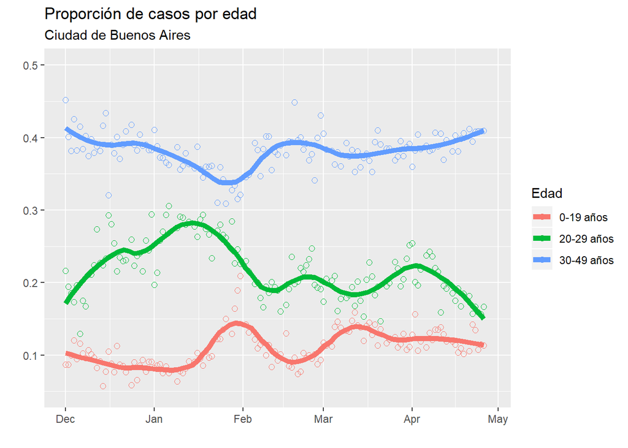

Como vemos, la proporción de casos en menores de 19 años es muy baja, no pasando del 15% del total. La suba de casos que hubo en diciembre para las fiestas de fin de año se debió mayormente a la franja de 20-29 años, que tiene más peso en el total. Del mismo modo, aunque los casos en menores de 19 años subió a principios de marzo para el comienzo de las clases, el verdadero problema se dió en la franja de 20-29 años. Por eso el descenso que se observa actualmente en Capital Federal se debe mayormente a un descenso de casos en esta franja, no en los chicos de edad escolar.

## Casos y movilidad

¿Cuánto influye la movilidad general en la curva de casos? Para medir la movilidad, usamos los índices de Google Community Mobility Reports, que pueden encontrarse [acá](https://www.google.com/covid19/mobility/). Estos índices miden la movilidad de la gente en diferentes lugares usando datos del GPS de los celulares a los que Google tiene acceso (por ejemplo mediante Google Maps). Acá usamos como índice general de movilidad el promedio entre los índices de movilidad en lugares de compras y recreación, y en las estaciones de transporte público:

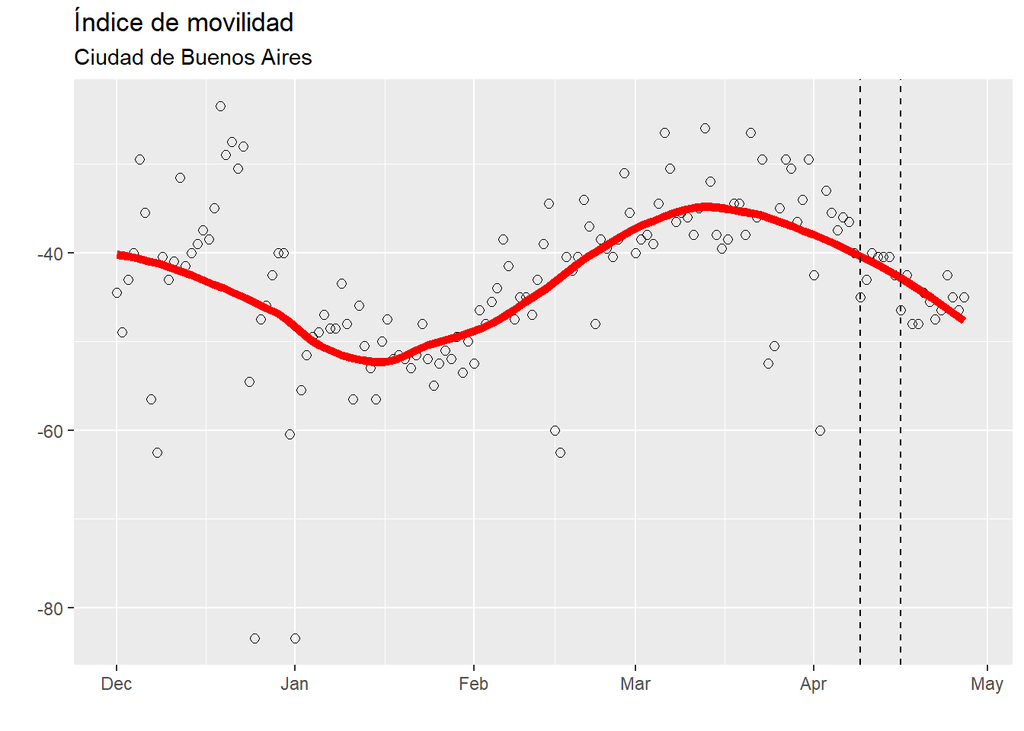

Como vemos, la movilidad es mínima en enero durante las vacaciones, empieza a subir en febrero, se ameseta en marzo, y empieza a disminuir en abril, **antes** de la entrada en vigencia de las nuevas medidas. Por otro lado, la curva de casos no empieza a subir en febrero sino que recién se dispara a mediados de marzo, cuando la curva de movilidad ya había estado amesetada por dos semanas. Esto muestra que no hay una relación muy fuerte entre movilidad general y aceleración en la curva de casos.

Podemos hacer un estudio más riguroso empleando el método de Badr y otros que apareció en un artículo de *The Lancet* (que se puede ver acá). Los autores definen un índice de aceleración de casos, C, como el cociente entre el promedio de casos diarios en los últimos tres días sobre el promedio de casos diarios en los últimos siete días. Cuando la curva de casos se acelera, el cociente C es mayor que 1, mientras que cuando la curva se desacelera, el cociente C es menor que 1. Si la movilidad general influyera en la aceleración de casos, uno esperaría ver una fuerte correlación entre el índice de movilidad y el cociente C una o dos semanas más tarde, pero este no es el caso, como muestra el siguiente gráfico:

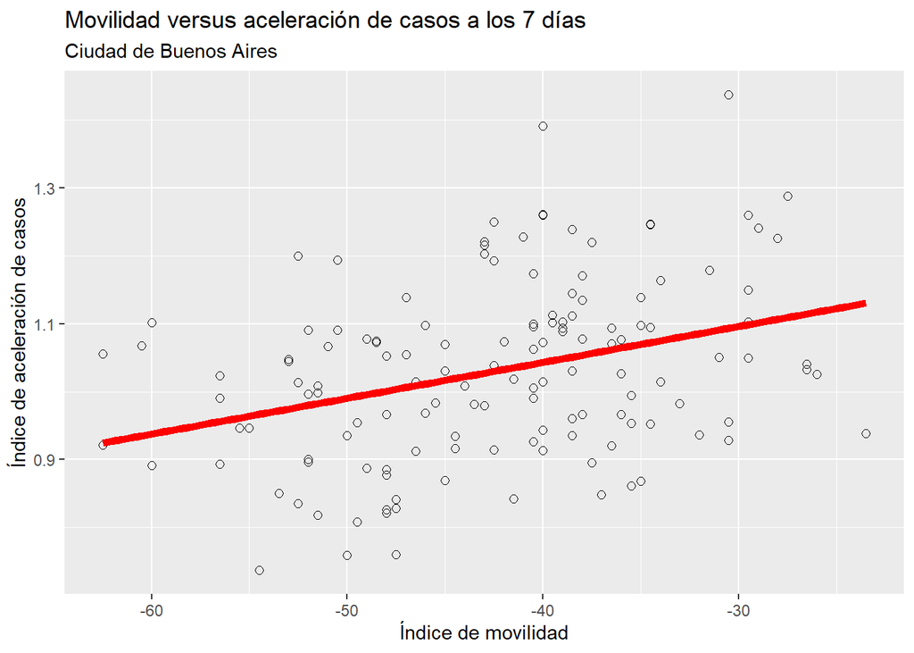

Este gráfico muestra una correlación entre el índice de movilidad y el coeficiente de aceleración de casos a los siete días, pero la correlación no es tan fuerte como podría suponerse. Concretamente, solo el 11% de la variabilidad en el coeficiente de aceleración se debe al índice de movilidad. El 89% de la variabilidad en el coeficiente de aceleración **no** está explicada por el índice de movilidad. (Resultados parecidos se obtienen estudiando la correlación a los 14 días.)

(Es interesante notar que otro artículo en *The Lancet*, posterior al de Badr que citábamos arriba (y que se puede ver acá), tampoco encontró una correlación fuerte entre movilidad general y velocidad de transmisión del virus.)

## Conclusiones

En Capital Federal el “tsunami” está en claro retroceso, pero esto no se debe a las medidas de restricción a la movilidad general ni a la suspensión de clases presenciales (que en Capital nunca se suspendieron). Tanto el rebrote de fin de año como el “tsunami” de abril se debieron mayormente a un aumento de casos en la franja etaria de 20 a 29 años. Son las conductas en este grupo lo que mayormente viene afectando la dinámica en la curva de casos desde diciembre.

[Back to blog](https://sites.uwm.edu/gervini/coronavirus-blog/)